# Tratamentos com oxigenoterapia em pacientes com bronquiolite

Diferenças entre os grupos de tratamento

Kevyn Andrade | Rayssa Souza - Universidade de Brasília

2021-09-23

# Metodologia

# Presença de reinternações por grupo de tratamento

$H_{0}: \textrm{A presença de reinternações é igual para ambos os grupos de tratamento}$

$H_{1}: \textrm{Há uma diferença na presença de reinternações entre os grupos de tratamento}$

Reinternações por Grupo

| P-valor | Conclusão |
| --- | --- |
| 0.9224197 | Aceita H0 |

O p-valor obtido é muito alto, de modo que não há evidências de associação entre tipo de tratamento com e a presença de reinternações.

# Grau de desconforto respiratório por grupo de tratamento

$H_{0}: \textrm{O grau de desconforto respiratório é igual em ambos os grupos de tratamento}$

$H_{1}: \textrm{Há uma diferença na no grau de desconforto entre os grupos de tratamento}$

Desconforto por Grupo

| P-valor | Conclusão |
| --- | --- |
| 0.0009266 | Rejeita H0 |

O p valor foi extremamente pequeno, mostrando evidências de que o tipo de tratamento está ligado ao grau de desconforto do paciente.

Verificando qual tratamento apresenta mais casos graves de desconforto respiratório:

|  | Oxigenoterapia | Oxigenoterapia + Outros |
| --- | --- | --- |
| Grave | 0.0357143 | 0.9642857 |
| Leve | 0.4516129 | 0.5483871 |
| Moderado | 0.2307692 | 0.7692308 |

O tratamento de “Oxigenoterapia + Outros” tem mais casos graves em relação ao tratamento de “Oxigenoterapia”, de modo que “Oxigenoterapia + Outros” apresenta um maior grau de desconforto.

# Melhora nos sinais de desconforto respiratório

$H_{0}: \textrm{A melhora nos sinais de desconforto respiratório não está associada com o grupo de tratamento}$

$H_{1}: \textrm{Há associação entre grupo melhora nos sinais de desconforto e grupo de tratamento}$

Melhora dos sinais de desconforto respiratório por Grupo

| P-valor | Conclusão |
| --- | --- |
| 0.0960467 | Aceita H0 |

Não há evidência significativa de associação entre tipo de tratamento e melhora nos sinais de desconforto respiratório.

# Presença de Complicações

$H_{0}: \textrm{A presença de complicações não está associada com o grupo de tratamento}$

$H_{1}: \textrm{Há associação entre presença de complicações e grupo de tratamento}$

Complicações por Grupo

| P-valor | Conclusão |
| --- | --- |
| 0.4508526 | Aceita H0 |

Não existe evidência significativa de associação entre tipo de tratamento e a presença de complicações.

# Tempo de Internação

$H_{0}: \textrm{O tempo de internação não está associada com o grupo de tratamento}$

$H_{1}: \textrm{Há associação entre tempo de internação e grupo de tratamento}$

Dado que há evidências contra a hipótese de normalidade, será usado o teste de Mann-Whitney-Wilcoxon.

Tempo por Grupo

| P-valor | Conclusão |
| --- | --- |
| 0.9086081 | Aceita H0 |

Não há evidências de associação significativa entre tipo de tratamento e tempo de internação.

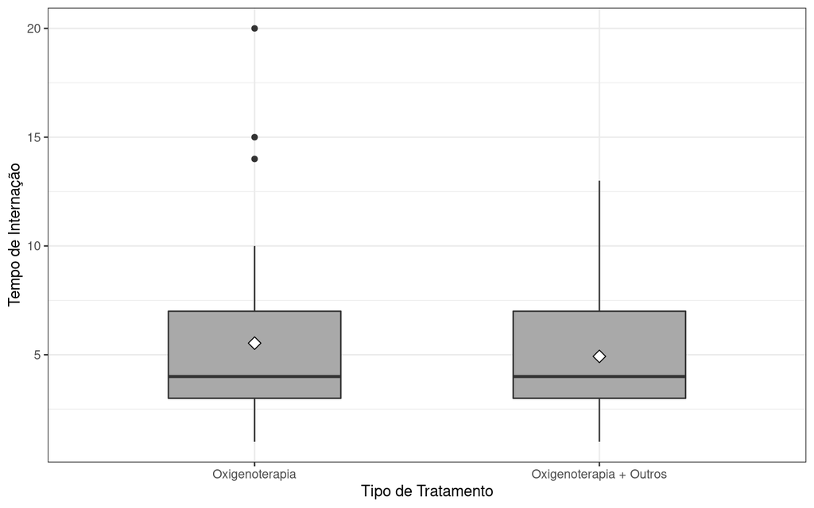

# Quantidade de Litros de Oxigênio

$H_{0}: \textrm{A quantidade de litros de oxigênio não está associada com o grupo de tratamento}$

$H_{1}: \textrm{Há associação entre quantidade de litros de oxigênio e grupo de tratamento}$

Há evidências contra a hipótese de normalidade. Será usado o teste de Mann-Whitney-Wilcoxon.

Oxigênio por Grupo

| P-valor | Conclusão |
| --- | --- |
| 0.0009952 | Rejeita H0 |

Há evidências de associação entre tipo de tratamento e a quantidade de litros de oxigênio.

|  | Oxigenoterapia | Oxigenoterapia + Outros |
| --- | --- | --- |
| 0.5 | 1.0000000 | 0.0000000 |
| 1 | 0.3437500 | 0.6562500 |
| 1.5 | 0.0000000 | 1.0000000 |
| 2 | 0.0909091 | 0.9090909 |
| 6 | 0.5000000 | 0.5000000 |
| 8 | 0.0000000 | 1.0000000 |
| 9 | 0.0000000 | 1.0000000 |

# Melhora na Saturação de Oxigênio

$H_{0}: \textrm{A melhora na saturação do oxigênio não está associada com o grupo de tratamento}$

$H_{1}: \textrm{Há associação entre melhora na saturação do oxigênio e grupo de tratamento}$

Há evidências contra a hipótese de normalidade da saturação.

Saturação por Grupo

| P-valor | Conclusão |
| --- | --- |
| 0.2212368 | Aceita H0 |

Não há evidências de associação do tipo de tratamento com a melhora na saturação de oxigênio.